# ATSB modelling framework

Nima Moghaddas

2023-06-06

## What are we trying to do?

The ATSB trials currently underway are assessing the efficacy of ATSB as an intervention against malaria. We would like to develop a modelling framework to estimate the impact of ATSB based on the available baseline data from the trials. These estimates could be validated against data collected during the trial to assess the success of the model. We want to use the ASB dyed fraction estimates.

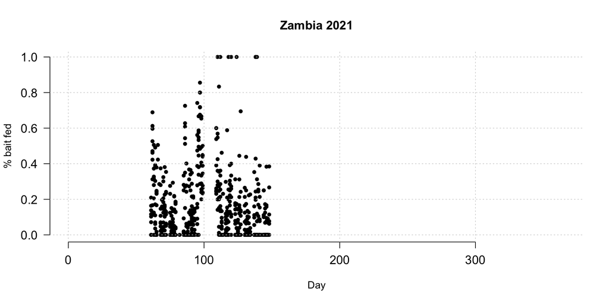

```r
mali <- read.csv("~/Documents/GitHub/atsb_working_code/DB monthly natural sugar and ASB feeding/day 2-Table 1.csv")[-(64:65),]
mali$dyed_fraction <- mali$females.ASB.positive/mali$TOTAL.Sample.females.Day.2
mali$total_asb_positive <- mali$females.ASB.positive
mali$total_sampled <- mali$TOTAL.Sample.females.Day.2
mali$days <- (mali$month-1)*30+mali$Day
zambia <- read.csv("~/Documents/GitHub/zambia_feeding_data")
zambia$days <- (month(zambia$collection_date)-1)*30 + day(zambia$collection_date)
par(las=1)
zambia |>
  group_by(collection_date, cluster) |>
  summarise(dyed_fraction = sum(positive)/n()) -> zambia_grouped
zambia_grouped$days <- (month(zambia_grouped$collection_date)-1)*30 + day(zambia_grouped$collection_date)
plot(zambia_grouped$days,
     zambia_grouped$dyed_fraction,
     cex=1.1, pch=20, frame.plot = F, xlab = "Day", ylab = "% bait fed",
     ylim = c(0,1), cex.axis=1.2, xlim = c(1,365))
grid()
title("Zambia 2021")
```

As can be seen, data is only available for a fraction of the year, roughly three months, and there is substantial variability in the data, with a range of dyed fractions from 0 to 100% on different days in different clusters. At what level to characterise the dyed fraction is an important question. The ATSB trials are intended to run for two years, so another question is how we will extrapolate this limited data. I will attempt a framework that follows the following steps:

1. Characterise a time constant dyed fraction at the cluster level
2. Characterise a time variable dyed fraction at the cluster level
3. Convert dyed fraction into daily feeding rate
4. Prepare model with site specific parameters
5. Generate predictions of the impact of ATSB
6. Compare predictions to trial data

## Step 1

To generate time constant dyed fraction estimates for each cluster we can run a binomial regression on dye positivity for each species with fixed effects for cluster.

```r
zambia$mosquito_species <- factor(zambia$mosquito_species)
funestus <- filter(zambia, mosquito_species == 'funestus')
fit1 <- glmer(
  positive ~ cluster + (1|days) - 1,
  data = funestus, family = "binomial", control = glmerControl(optimizer = "bobyqa")
)
funestus_dyed_fraction <- cbind(plogis(fixef(fit1)),
                        plogis(fixef(fit1)-1.96*summary(fit1)$coefficients[,2]),
                        plogis(fixef(fit1)+1.96*summary(fit1)$coefficients[,2]))
funestus_dyed_fraction <- jensen.logit.adjust(p = funestus_dyed_fraction, V = sum(unlist(VarCorr(fit1))))
gambiae <- filter(zambia, mosquito_species == 'gambiae')
fit2 <- glmer(
  positive ~ cluster + (1|days) - 1,
  data = gambiae, family = "binomial", control = glmerControl(optimizer = "bobyqa")
)
gambiae_dyed_fraction <- cbind(plogis(fixef(fit2)),
                        plogis(fixef(fit2)-1.96*summary(fit2)$coefficients[,2]),
                        plogis(fixef(fit2)+1.96*summary(fit2)$coefficients[,2]))
gambiae_dyed_fraction <- jensen.logit.adjust(p = gambiae_dyed_fraction, V = sum(unlist(VarCorr(fit1))))
colnames(gambiae_dyed_fraction) <- colnames(funestus_dyed_fraction) <- c("Mean", "2.5%", "97.5%")
round(cbind(funestus_dyed_fraction, gambiae_dyed_fraction), digits = 3)
```

```
##                   Mean  2.5% 97.5%  Mean  2.5% 97.5%
## clusterasb13.23  0.138 0.111 0.169 0.052 0.025 0.106
## clusterasb143.23 0.191 0.160 0.226 0.086 0.047 0.152
## clusterasb151.32 0.190 0.155 0.230 0.120 0.054 0.240
## clusterasb158.32 0.131 0.100 0.170 0.026 0.004 0.150
## clusterasb163.23 0.182 0.154 0.213 0.126 0.080 0.192
## clusterasb194.32 0.186 0.157 0.219 0.068 0.035 0.124
## clusterasb33.32  0.186 0.157 0.218 0.095 0.055 0.159
## clusterasb45.23  0.247 0.212 0.286 0.134 0.080 0.212
## clusterasb77.23  0.195 0.166 0.227 0.162 0.113 0.225
## clusterasb84.32  0.213 0.181 0.248 0.159 0.102 0.236
```

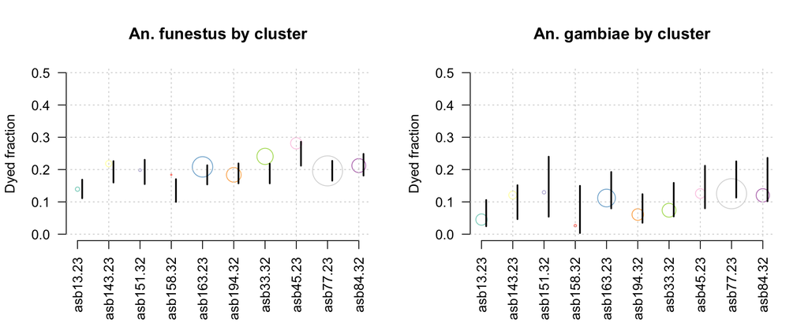

```r
# Visualise
funestus |>
  group_by(cluster) |>
  summarise(positive = mean(positive), count=n()) -> zambia_grouped
par(las=2, mfrow=c(1,2))
plot(zambia_grouped$positive,
     col=brewer.pal(10,"Set3")[factor(zambia_grouped$cluster)],
     cex=2*zambia_grouped$count/mean(zambia_grouped$count),
     frame.plot = F,
     ylim = c(0,0.5),
     ylab = "Dyed fraction",
     xaxt = "n",
     xlab = "")
axis(1, at=1:10, labels=unique(zambia_grouped$cluster))
grid()
arrows(1:10+0.15,
       funestus_dyed_fraction[,2],
       1:10+0.15,
       funestus_dyed_fraction[,3],
       code=0,
       lwd=2)
title("An. funestus by cluster")

gambiae |>
  group_by(cluster) |>
  summarise(positive = mean(positive), count=n()) -> zambia_grouped
plot(zambia_grouped$positive,
     col=brewer.pal(10,"Set3")[factor(zambia_grouped$cluster)],
     cex=2*zambia_grouped$count/mean(zambia_grouped$count),
     frame.plot = F,
     ylim = c(0,0.5),
     ylab = "Dyed fraction",
     xaxt = "n",
     xlab = "")
axis(1, at=1:10, labels=unique(zambia_grouped$cluster))
grid()
arrows(1:10+0.15,
       gambiae_dyed_fraction[,2],
       1:10+0.15,
       gambiae_dyed_fraction[,3],
       code=0,
       lwd=2)
title("An. gambiae by cluster")
```

## Step 2

To generate time varying dyed fraction estimates for each cluster we can run a binomial regression on dye positivity for each species with fixed effects for cluster and month.

```r
zambia$month_caught <- factor(zambia$month_caught)
fit3 <- glmer(
  positive ~ cluster + month_caught + (1|days) - 1,
  data = funestus, family = "binomial", control = glmerControl(optimizer = "bobyqa")
)
summary(fit3)
```

```
## Generalized linear mixed model fit by maximum likelihood (Laplace
##   Approximation) [glmerMod]
##  Family: binomial  ( logit )
## Formula: positive ~ cluster + month_caught + (1 | days) - 1
##    Data: funestus
## Control: glmerControl(optimizer = "bobyqa")
##
##      AIC      BIC   logLik deviance df.resid
##  37209.6  37313.0 -18592.8  37185.6    40832
##
## Scaled residuals:
##     Min      1Q  Median      3Q     Max
## -1.6070 -0.5057 -0.3496 -0.2234  6.5953
##
## Random effects:
##  Groups Name        Variance Std.Dev.
##  days   (Intercept) 0.8753   0.9356
## Number of obs: 40844, groups:  days, 65
##
## Fixed effects:
##                  Estimate Std. Error z value Pr(>|z|)
## clusterasb13.23    0.2516     0.3913   0.643  0.52021
## clusterasb143.23   0.6764     0.3856   1.754  0.07942 .
## clusterasb151.32   0.6723     0.3927   1.712  0.08690 .
## clusterasb158.32   0.1836     0.3999   0.459  0.64622
## clusterasb163.23   0.6148     0.3845   1.599  0.10988
## clusterasb194.32   0.6506     0.3856   1.687  0.09153 .
## clusterasb33.32    0.6448     0.3846   1.676  0.09368 .
## clusterasb45.23    1.0483     0.3850   2.723  0.00647 **
## clusterasb77.23    0.7103     0.3847   1.847  0.06482 .
## clusterasb84.32    0.8294     0.3845   2.157  0.03098 *
## month_caught      -0.5929     0.0965  -6.145 8.02e-10 ***
## ---
## Signif. codes:  0 '***' 0.001 '**' 0.01 '*' 0.05 '.' 0.1 ' ' 1
##
## Correlation of Fixed Effects:
##             c13.23 c143.2 c151.3 c158.3 c163.2 c194.3 c33.32 c45.23 c77.23
## clstr143.23  0.968
## clstr151.32  0.954  0.964
## clstr158.32  0.925  0.934  0.921
## clstr163.23  0.975  0.986  0.971  0.941
## clstr194.32  0.974  0.984  0.970  0.939  0.991
## clstrs33.32  0.975  0.985  0.971  0.941  0.992  0.990
## clstrs45.23  0.974  0.984  0.970  0.940  0.991  0.989  0.990
## clstrs77.23  0.976  0.987  0.972  0.942  0.994  0.992  0.993  0.992
## clstrs84.32  0.974  0.984  0.970  0.940  0.991  0.990  0.991  0.990  0.992
## month_caght -0.932 -0.942 -0.928 -0.899 -0.949 -0.947 -0.948 -0.947 -0.950
##             c84.32
## clstr143.23
## clstr151.32
## clstr158.32
## clstr163.23
## clstr194.32
## clstrs33.32
## clstrs45.23
## clstrs77.23
## clstrs84.32
## month_caght -0.947
```

```r
plogis(fixef(fit3))
```

```
##  clusterasb13.23 clusterasb143.23 clusterasb151.32 clusterasb158.32
##        0.5625790        0.6629344        0.6620277        0.5457631
## clusterasb163.23 clusterasb194.32  clusterasb33.32  clusterasb45.23
##        0.6490261        0.6571525        0.6558329        0.7404492
##  clusterasb77.23  clusterasb84.32     month_caught
##        0.6704685        0.6962327        0.3559605
```

## Step 5

We can then validate our predictions against the trial data.